# Predicting MOOC Completion from Early Engagement Patterns

Analysis of FutureLearn Cyber Security Course Data

Nepoliyan Ria

January 16, 2026

# Executive Summary

This report analyzes seven runs of the FutureLearn MOOC “Cyber Security: Safety at Home, Online, and in Life” using two CRISP-DM cycles to test whether early engagement predicts course completion.

**Key findings**

- **Completion rate:** 5.8%
- **Activation rate:** 56.3%
- **Week 1 predictor:** High Week 1 engagers (≥75% complete) reach 26.2% completion vs. 0.1% for very low engagers
- **Practical threshold:** Flag learners completing <40% of Week 1 by day 7

# Introduction

## Dataset

Seven runs of the course:

- Enrolments: **37,296**
- Step interactions: **423,072**

## Research question

Can early-course engagement predict whether learners complete a MOOC?

# Cycle 1: Overall engagement and completion

## Summary statistics

Overall Enrollment and Completion Statistics

| Metric | Value |
| --- | --- |
| Total Enrollments | 37,296 |
| Active Learners (≥1 step) | 20,991 |
| Learners Who Completed | 2,154 |
| Activation Rate | 56.3% |
| Completion Rate (all enrolled) | 5.8% |
| Completion Rate (active only) | 9.8% |

## Completion funnel

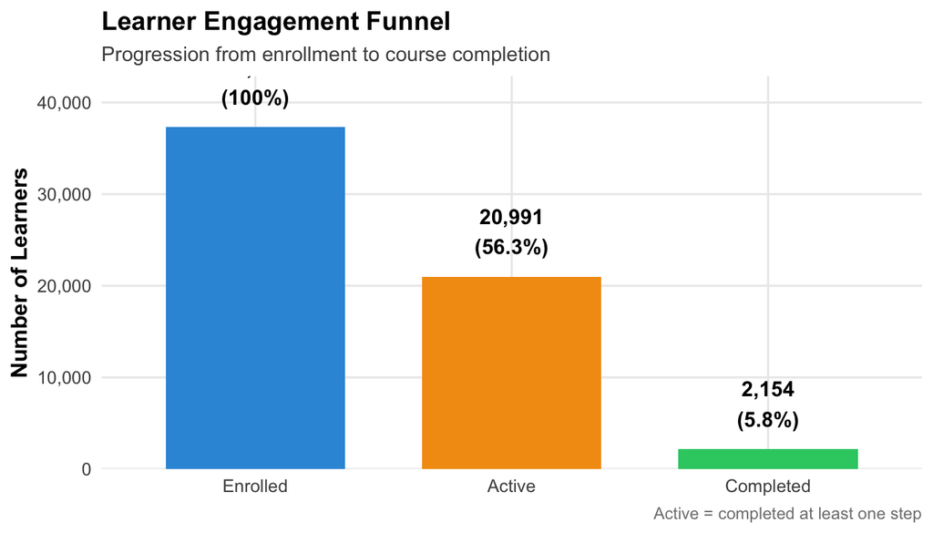

Learner progression from enrollment to completion

## Steps completed distribution

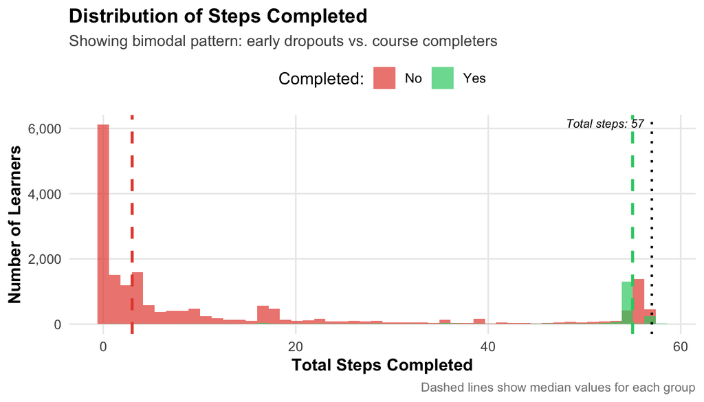

Bimodal distribution shows early dropouts vs. completers

## Engagement comparison

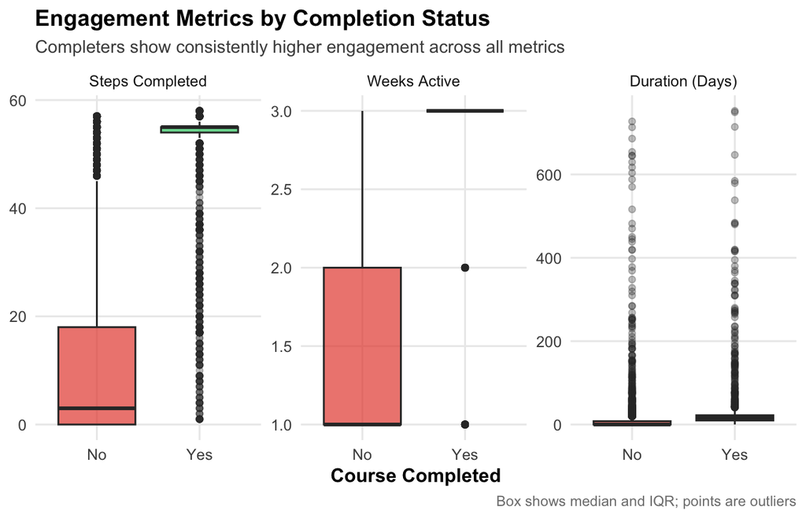

Completers show higher engagement across all metrics

## Retention by week

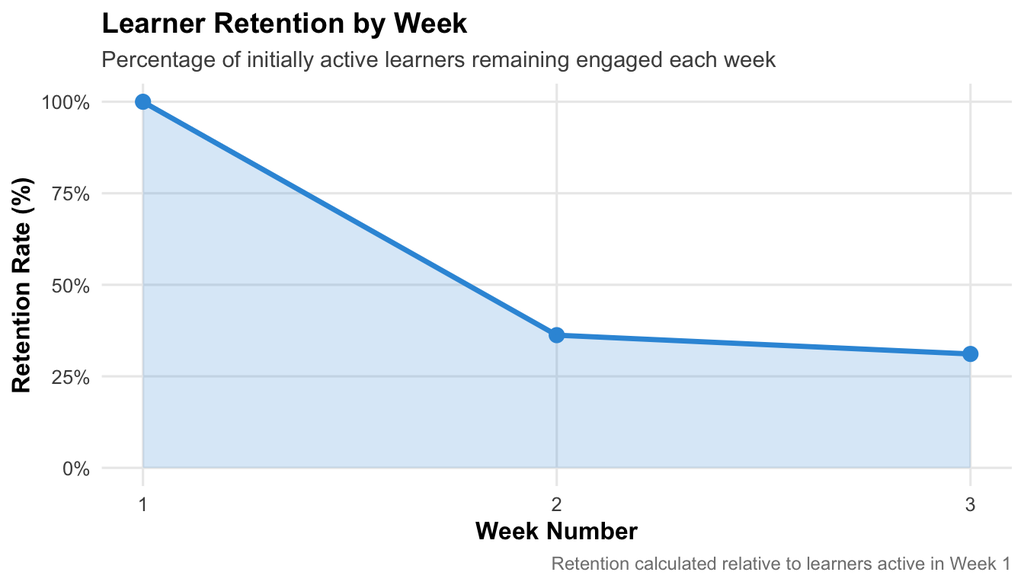

Retention drops sharply in early weeks

## Key takeaways (Cycle 1)

- 43.7% of enrolled learners never activate.
- Engagement is bimodal (early dropouts vs. persisters).
- Most dropout happens in Weeks 1–3.

# Cycle 2: Week 1 engagement as predictor

## Week 1 distribution

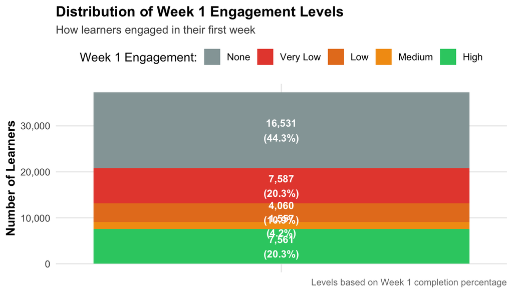

Distribution of Week 1 engagement levels

## Completion by Week 1 engagement level

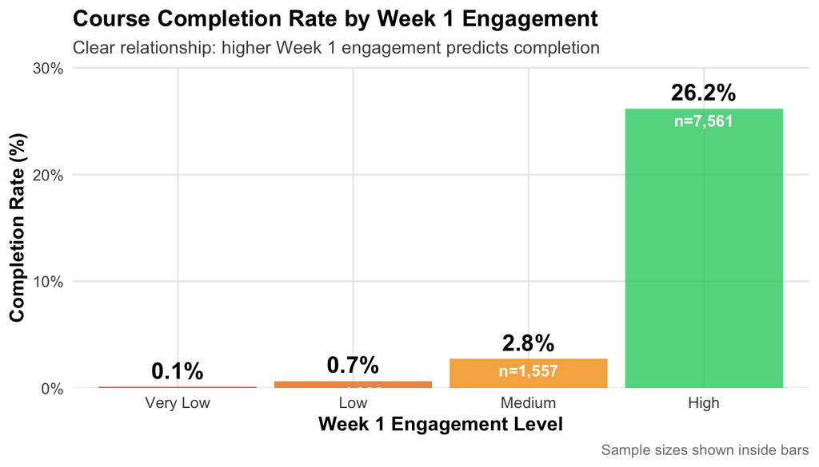

Completion rate increases with Week 1 engagement

Completion Rates by Week 1 Engagement Level

| Week 1 Engagement | N | Completion Rate |
| --- | --- | --- |
| Very Low | 7587 | 0.1% |
| Low | 4060 | 0.7% |
| Medium | 1557 | 2.8% |
| High | 7561 | 26.2% |

## Key takeaways (Cycle 2)

- Completion increases monotonically with Week 1 engagement.
- A practical early-warning threshold is **<40% Week 1 completion**.

# Overall conclusions

Week 1 engagement is a strong early indicator of MOOC completion. Learners completing ≥75% of Week 1 achieve a completion rate of 26.2% versus 0.1% for very low engagers.

Flagging learners below 40% Week 1 completion by day 7 supports timely, targeted intervention.

# Appendix: Technical details

- **R version:** R version 4.5.2 (2025-10-31)
- **ProjectTemplate version:** 0.11.1
- **Generated:** 2026-01-16 06:07:17.817742
- **Key libraries:** `ProjectTemplate`, `dplyr`, `tidyr`, `ggplot2`, `knitr`, `kableExtra`, `lubridate`, `scales`, `stringr`, `readr`, `tibble`
- **Reproducibility:** Run `library(ProjectTemplate); load.project()` then knit from `reports/`